# tidy

2018-02-16

### tidy

- data structure
- workflow
- tool suite

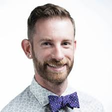

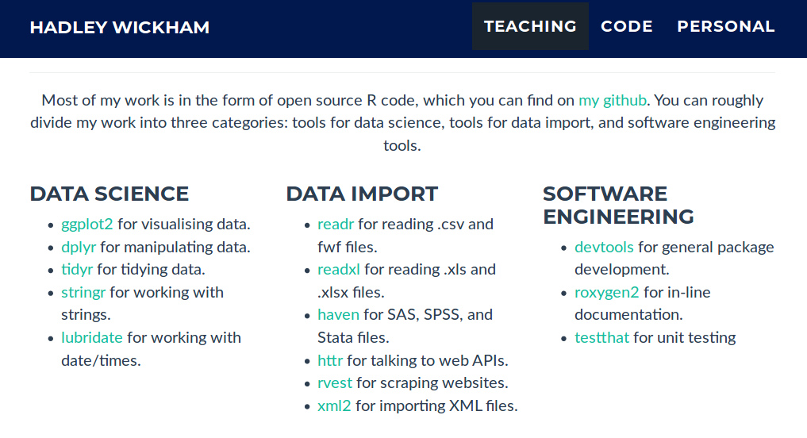

[figure not shown]

### data structure: tidy data

- each variable in a column
- each observation in a row
- each value in a cell

[figure not shown]

Open an intro to ANY statistics textbook…

“To the Tidyverse and Beyond: Challenges for the Future in Data Science”, D. Cook, bit.ly/rstudio-cook

[figure not shown]

“To the Tidyverse and Beyond: Challenges for the Future in Data Science”, D. Cook, bit.ly/rstudio-cook

…and you will find that statistics (analysis, plotting - anything, really) starts once you have tidy data

“To the Tidyverse and Beyond: Challenges for the Future in Data Science”, D. Cook, bit.ly/rstudio-cook

### workflow

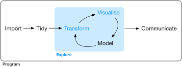

It is often said that 80% of data analysis is spent on the process of cleaning and preparing the data  
Dasu and Johnson 2003

All data are crap, it is just a matter of how much work you have to do to make them useful.  
good ol' Ben

Grolemund, G. and H. Wickham. 2001. R for Data Science; Wickham, H. 2014. Tidy Data

### write for humans

Programs must be written for people to read, and only incidentally for machines to execute.  
Hal Abelson

```
  new_thing <- thing %>%
    do something to thing %>%
    do something to thing %>%
    do something to thing
```

Tidyverse, Hadley Wickham, https://speakerdeck.com/hadley/tidyverse

### tidyverse

[figure not shown]